# Urban Big Data Analytics - Lecture 10 Group Session: Advanced Modeling

Andy Hong

July 31, 2019

## Prerequisites

Please locate your `vsp_bigdata` folder under “My Documents” and navigate to `group-session`. Create `10-lecture` folder under the `group-session` folder.

For this group session, we will use the 2011 Gapminder database.  
Please download this CSV file and save it under the group session folder: [Gapminder data 2011](https://urbanbigdata.github.io/10-lecture-advanced_modeling/group-session/gapminder_data_2011.csv)

## Instruction

### 1. Synopsis

The purpose of this group session is to understand the concept of **logistic regression**.

First, we will build a logistic regression model using Exploratory. Then, we will build a logistic regression model using R Studio.

### 2. Part one - Building a logistical model in Exploratory

Go to `Analytics` and choose `Logistic Regression Analysis` for the type.  
Your target variable is `corruption`, and your predictor variable(s) are: `income`, `population`, and `democracy`.

Mathematically, what we are trying to estimate is the following function.

$logit(p) = log(\frac{p}{1-p}) = \beta_{0} + \beta_{1}x_{1} + \beta_{2}x_{2} + \beta_{3}x_{3}$

where $log(\frac{p}{1-p})$ is the log odds of being in corruption; $x_{1}$is income; $x_{2}$is population; and $x_{3}$is democracy.

### 3. Part two - Building a logistical model in R Studio

We are going to join the gapminder data with the corruption data. Let’s load the libraries first.

```r
# Set CRAN repository source
options(repos="https://cran.rstudio.com")

# Install packages
# install.packages("dplyr")
# install.packages("magrittr")

# Load packages
library(dplyr)
library(magrittr)
```

Let’s load and examine the gapminder data.

```r
gapminder = read.csv("/Users/andyhong/Documents/vsp_bigdata/group-session/10-lecture/gapminder_data_2011.csv")

head(gapminder)
```

```
##          name   region population income lifeExp democracy corruption
## 1 Afghanistan     asia   29700000   1660    56.7        NA          1
## 2     Albania   europe    2930000  10200    76.7         9          1
## 3     Algeria   africa   36800000  13000    76.7         2          1
## 4      Angola   africa   24200000   5910    60.9        -2          1
## 5   Argentina americas   41700000  19600    76.0         8          1
## 6     Armenia   europe    2880000   7020    73.8         5          1
##   corruption_index
## 1                8
## 2               33
## 3               34
## 4               22
## 5               35
## 6               34
```

We are going to build the basic and the full models. We will use the `glm` function, which is a generalized linear model function. We will use the binomial family to implement the logistic function.

```r
model1 = glm(data = gapminder, corruption ~ income, family = binomial)
model2 = glm(data = gapminder, corruption ~ income + population + democracy, family = binomial)
```

Now we can see the results of the models using the `summary` function.

```r
# Show the original results
summary(model1)
```

```
##
## Call:
## glm(formula = corruption ~ income, family = binomial, data = gapminder)
##
## Deviance Residuals:
##     Min       1Q   Median       3Q      Max
## -2.4951   0.2889   0.3345   0.4841   3.2432
##
## Coefficients:
##               Estimate Std. Error z value Pr(>|z|)
## (Intercept)  3.223e+00  4.378e-01   7.362 1.82e-13 ***
## income      -1.094e-04  1.787e-05  -6.120 9.37e-10 ***
## ---
## Signif. codes:  0 '***' 0.001 '**' 0.01 '*' 0.05 '.' 0.1 ' ' 1
##
## (Dispersion parameter for binomial family taken to be 1)
##
##     Null deviance: 180.52  on 160  degrees of freedom
## Residual deviance: 114.34  on 159  degrees of freedom
## AIC: 118.34
##
## Number of Fisher Scoring iterations: 5
```

```r
summary(model2)
```

```
##
## Call:
## glm(formula = corruption ~ income + population + democracy, family = binomial,
##     data = gapminder)
##
## Deviance Residuals:
##     Min       1Q   Median       3Q      Max
## -3.2691  -0.0196   0.1788   0.4261   2.3690
##
## Coefficients:
##               Estimate Std. Error z value Pr(>|z|)
## (Intercept)  4.520e+00  7.187e-01   6.289 3.19e-10 ***
## income      -1.143e-04  2.037e-05  -5.612 2.01e-08 ***
## population   7.916e-09  5.854e-09   1.352 0.176304
## democracy   -2.244e-01  5.983e-02  -3.751 0.000176 ***
## ---
## Signif. codes:  0 '***' 0.001 '**' 0.01 '*' 0.05 '.' 0.1 ' ' 1
##
## (Dispersion parameter for binomial family taken to be 1)
##
##     Null deviance: 178.788  on 157  degrees of freedom
## Residual deviance:  92.263  on 154  degrees of freedom
##   (3 observations deleted due to missingness)
## AIC: 100.26
##
## Number of Fisher Scoring iterations: 6
```

For interpretation, we can exponentiate the results to get the odds ratio.

```r
# Show the exponentiated results
exp(cbind(Odds=coef(model1), confint(model1)))
```

```
##                   Odds      2.5 %    97.5 %
## (Intercept) 25.0937760 11.4025724 64.308892
## income       0.9998906  0.9998524  0.999923
```

```r
exp(cbind(Odds=coef(model2), confint(model2)))
```

```
##                   Odds      2.5 %      97.5 %
## (Intercept) 91.8588022 26.2262274 451.8015542
## income       0.9998857  0.9998411   0.9999217
## population   1.0000000  1.0000000   1.0000000
## democracy    0.7989896  0.7001597   0.8887006
```

Now, we can also generate the coefficient plot using the `plot_summs` function from the `jtools` package. To get the exponentiated results, we will use the option `exp=TRUE`.

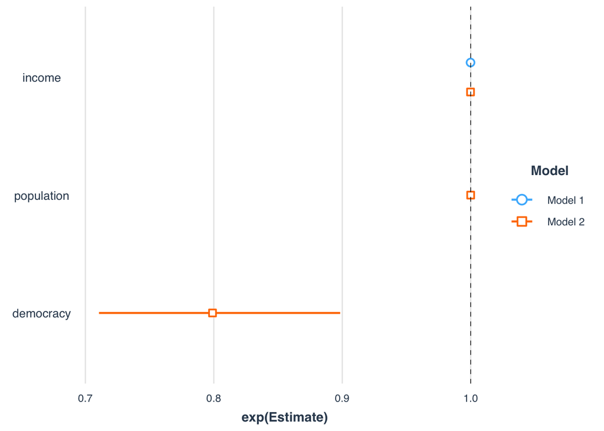

```r
# Load the jtools package
library(jtools)

# Show coefficient plot
plot_summs(model1, model2, exp=TRUE)
```

## Send your report with the logistic model results and the interpretation

1. Use either Exploratory or R Studio to develop the best fit logistic model to estimate corruption
2. Create a short report that includes the model results and interpret your results.
3. Send your report to the course email (urbanbigdata2019@gmail.com).
- **[IMPORTANT]** Please use the following email title format:  
  `VSP BigData [lecture number] - [group number] - [presenter name]`  
  ex), `VSP BigData Lecture 11 - Group 1 - Bill Gates`